# ZPER - 2nd Competition (Predict Opening & Closing of Hospitals)

Ali Ezzat

September 15, 2018

## ————————————————————————————————-

## Overview

The data for this competition contains information on 430 hospitals gathered from various data sets, including historical financial statements, geographical (location) information, number of sickbeds, etc., for hospitals in South Korea. The main goal of this competition is to predict closing numbers of given hospitals. More information about this competition (and its dataset) may be found at [this link](http://dacon.io/cpt2/10397).

## ————————————————————————————————-

## First Look at the Data

We start by loading the necessary packages.

```r
library(tidyverse)
```

```r
library(ggcorrplot)
```

Next, we load the data from their respective files.

```r
train_dta <- read_csv("train.csv", col_names = TRUE, trim_ws = TRUE)  # load training data
test_dta  <- read_csv("test.csv",  col_names = TRUE, trim_ws = TRUE)  # load testing data
```

Let’s inspect the data!

```r
# initial look at the data
glimpse(train_dta)
```

```
## Observations: 301
## Variables: 58
## $ inst_id            <int> 1, 3, 4, 7, 9, 11, 14, 15, 16, 17, 18, 19, ...
## $ OC                 <chr> "open", "open", "open", "open", "open", "op...
## $ sido               <chr> "choongnam", "gyeongnam", "gyeonggi", "inch...
## $ sgg                <int> 73, 32, 89, 141, 32, 155, 169, 66, 91, 4, 9...
## $ openDate           <int> 20071228, 19970401, 20161228, 20000814, 200...
## $ bedCount           <int> 175, 410, 468, 353, 196, 243, 213, 250, 280...
## $ instkind           <chr> "nursing_hospital", "general_hospital", "nu...
## $ revenue1           <dbl> 4217530010, NA, 1004521989, 72507342181, 49...
## $ salescost1         <dbl> 0, NA, 515483669, 0, 0, 9222996930, 4449958...
## $ sga1               <dbl> 3961134739, NA, 447219722, 70677397660, 476...
## $ salary1            <dbl> 2033835290, NA, 296402310, 31786048663, 244...
## $ noi1               <dbl> 15652441, NA, 76156, 506223059, 112352259, ...
## $ noe1               <dbl> 15236236, NA, 30000, 1259567512, 1419089382...
```

[output cut: 45 more lines]

On first glance, we observe a number of things:

- A couple of the variables that are parsed as `integer` seem to be binary variables in actuality (i.e. `receivableL1`, `receivableL2`). *Note: This turns out to be incorrect later*.
- Some nomimal textual variables are parsed as `character` (e.g. `ownerChange`, `instkind`). These need to be convert to type `factor`.
- Multiple variables have `NA` values in them.
- The variables, `employee1` and `employee2`, are both numerical variables while, at the same time, they were parsed as type `character`.

The `NA` values problem seems to be the most annoying, so let’s start with it. Let’s see which variables have NA values in them and how frequently `NA` values occur in them.

```r
# show NA-containing variables and how frequently these NAs occur in each
train_dta %>%
  map_df(is.na) %>%              # turn into an is.na() matrix
  select_if(colSums(.) > 0) %>%  # get columns whose sum > 0  (i.e. variables which contain at least 1 NA value)
  colSums() %>%                  # how many NA values do these variables contain?
  t() %>%
  t()
```

```
##                    [,1]
## bedCount              5
## instkind              1
## revenue1              8
## salescost1            8
## sga1                  8
## salary1               8
## noi1                  8
## noe1                  8
## interest1             8
## ctax1                 8
## profit1               8
## liquidAsset1          8
## quickAsset1           8
## receivableS1          8
## inventoryAsset1       8
## nonCAsset1            8
## tanAsset1             8
## OnonCAsset1           8
## receivableL1          8
## debt1                 8
## liquidLiabilities1    8
## shortLoan1            8
## NCLiabilities1        8
## longLoan1             8
## netAsset1             8
## surplus1              8
## revenue2              8
## salescost2            8
## sga2                  8
## salary2               8
## noi2                  8
## noe2                  8
## interest2             8
## ctax2                 8
## profit2               8
## liquidAsset2          8
## quickAsset2           8
## receivableS2          8
## inventoryAsset2       8
## nonCAsset2            8
## tanAsset2             8
## OnonCAsset2           8
## receivableL2          8
## debt2                 8
## liquidLiabilities2    8
## shortLoan2            8
## NCLiabilities2        8
## longLoan2             8
## netAsset2             8
## surplus2              8
## employee1            10
## employee2            13
## ownerChange          12
```

```r
# indices of rows (instances) containing NA values in them
row_indices <-
  train_dta %>%
  map_df(is.na) %>%                              # turn into an is.na() matrix
  transmute(rowHasNAvalue = rowSums(.) > 0) %>%  # create variable indicating whether the row has an NA value
  as.matrix() %>%                                # convert into matrix (for the following 'which' function)
  which()                                        # return indices of rows having NA values
# display these row indices
cat('#instances with NA values:', length(row_indices), '\n', row_indices)
```

```
## #instances with NA values: 24
##  2 15 33 36 49 56 61 63 72 94 194 207 213 231 243 249 258 259 264 286 298 299 300 301
```

In the training data, 24 instances (out of 301) that have NA values in them. Let’s try viewing them using the `View()` function.

```r
train_dta[row_indices,] %>% View('train_data_NA_values')
```

Before moving on, let’s observe the `NA` values in the test data.

```r
# indices of rows (instances) containing NA values in them
row_indices <-
  test_dta %>%
  select(-OC) %>%
  map_df(is.na) %>%                              # turn into an is.na() matrix
  transmute(rowHasNAvalue = rowSums(.) > 0) %>%  # create variable indicating whether the row has an NA value
  as.matrix() %>%                                # convert into matrix (for the following 'which' function)
  which()                                        # return indices of rows having NA values

# display these row indices
cat('#instances with NA values:', length(row_indices), '\n', row_indices)
```

```
## #instances with NA values: 25
##  3 11 14 16 21 23 41 53 57 79 83 84 85 89 94 100 105 113 114 121 123 124 125 126 127
```

In the test data, 25 instances (out of 127) have NA values in them. Let’s try viewing them using the `View()`

```r
test_dta[row_indices,] %>% View('test_data_NA_values')
```

A familiar pattern emerged which is: The same variables whose `NA` values co-occurred together in the same rows in the training data did so in the test data as well (i.e. the ones that specifically had 8 `NA` values in the training data). These variables are in the columns numbered 8 to 55 (in both the training and test data).

Before moving on, let’s convert the types of the variables, `employee1` and `employee2`, as numeric ones.

```r
train_dta$employee1 <- as.numeric(train_dta$employee1)
train_dta$employee2 <- as.numeric(train_dta$employee2)
test_dta$employee1  <- as.numeric(test_dta$employee1)
test_dta$employee2  <- as.numeric(test_dta$employee2)
glimpse(train_dta)
```

```
## Observations: 301
## Variables: 58
## $ inst_id            <int> 1, 3, 4, 7, 9, 11, 14, 15, 16, 17, 18, 19, ...
## $ OC                 <chr> "open", "open", "open", "open", "open", "op...
## $ sido               <chr> "choongnam", "gyeongnam", "gyeonggi", "inch...
## $ sgg                <int> 73, 32, 89, 141, 32, 155, 169, 66, 91, 4, 9...
## $ openDate           <int> 20071228, 19970401, 20161228, 20000814, 200...
## $ bedCount           <int> 175, 410, 468, 353, 196, 243, 213, 250, 280...
## $ instkind           <chr> "nursing_hospital", "general_hospital", "nu...
## $ revenue1           <dbl> 4217530010, NA, 1004521989, 72507342181, 49...
## $ salescost1         <dbl> 0, NA, 515483669, 0, 0, 9222996930, 4449958...
## $ sga1               <dbl> 3961134739, NA, 447219722, 70677397660, 476...
## $ salary1            <dbl> 2033835290, NA, 296402310, 31786048663, 244...
## $ noi1               <dbl> 15652441, NA, 76156, 506223059, 112352259, ...
## $ noe1               <dbl> 15236236, NA, 30000, 1259567512, 1419089382...
```

[output cut: 45 more lines]

Now, it’s time to dig deeper…

## ————————————————————————————————-

## Exploratory Data Analysis

Let’s explore the variables more closely using some visualizations. We’ll grab each and every one of the variables in the data and inspect them. Below are the variables that we will be looking at. A brief description for each of the variables in this dataset can be found in [this link](http://dacon.io/cpt2/10394).

```r
# the variables in the data
train_dta %>% colnames()
```

```
##  [1] "inst_id"            "OC"                 "sido"
##  [4] "sgg"                "openDate"           "bedCount"
##  [7] "instkind"           "revenue1"           "salescost1"
## [10] "sga1"               "salary1"            "noi1"
## [13] "noe1"               "interest1"          "ctax1"
## [16] "profit1"            "liquidAsset1"       "quickAsset1"
## [19] "receivableS1"       "inventoryAsset1"    "nonCAsset1"
## [22] "tanAsset1"          "OnonCAsset1"        "receivableL1"
## [25] "debt1"              "liquidLiabilities1" "shortLoan1"
## [28] "NCLiabilities1"     "longLoan1"          "netAsset1"
## [31] "surplus1"           "revenue2"           "salescost2"
## [34] "sga2"               "salary2"            "noi2"
## [37] "noe2"               "interest2"          "ctax2"
## [40] "profit2"            "liquidAsset2"       "quickAsset2"
## [43] "receivableS2"       "inventoryAsset2"    "nonCAsset2"
## [46] "tanAsset2"          "OnonCAsset2"        "receivableL2"
## [49] "debt2"              "liquidLiabilities2" "shortLoan2"
## [52] "NCLiabilities2"     "longLoan2"          "netAsset2"
## [55] "surplus2"           "employee1"          "employee2"
## [58] "ownerChange"
```

Observe that there are 24 variables that are repeated twice, once with the suffix `1` and once with the suffix `2`. The ones with suffix `1` pertain to the fiscal year of 2017, whereas those with the suffix `2` pertain to the fiscal year of 2016.

### OC: Open/Close (Target Variable)

The target variable is a binary indicator showing whether a hospital has closed since its inception or not.

```r
train_dta %>%
  select(OC) %>%
  group_by(OC) %>%
  summarise(count = n())
```

```
## # A tibble: 2 x 2
##   OC    count
##   <chr> <int>
## 1 close    15
## 2 open    286
```

Okay. So we now know that the ratio between open and closed hospitals is around 20:1 in the training data. Of course, we must bear in mind that this ratio could be quite different in the test data.

### sido: Local information of hospital

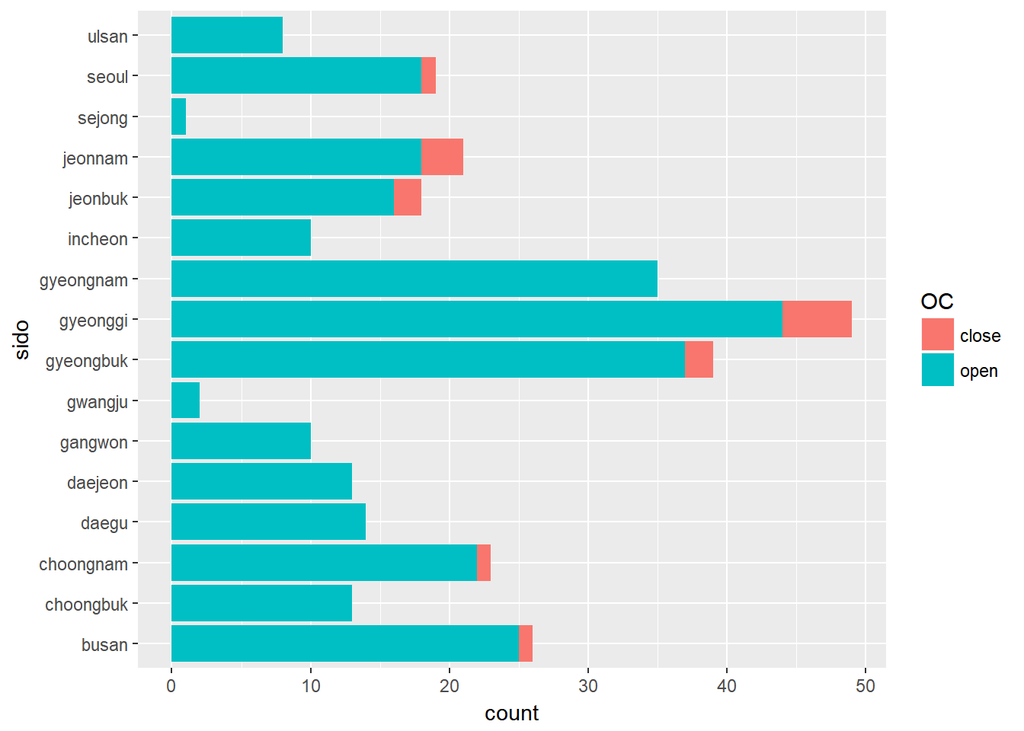

```r
train_dta %>%
  select(OC, sido) %>%
  ggplot(aes(x = sido, fill = OC)) +
  geom_bar() +
  coord_flip()
```

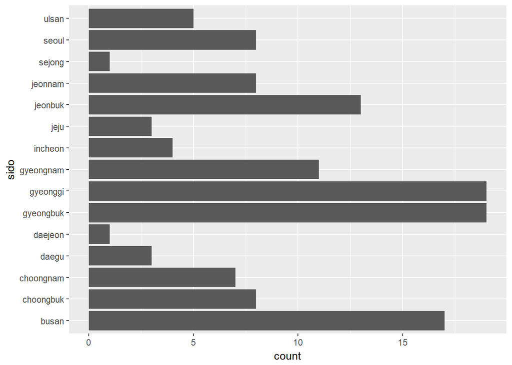

```r
test_dta %>%
  select(OC, sido) %>%
  ggplot(aes(x = sido)) +
  geom_bar() +
  coord_flip()
```

We can notice from the above plots that while most cities/provinces appear in both the training and test sets, there are a few that appear only one of them (i.e. `jeju`, `gwangju`, `gangwon`)

### sgg: Local detail information of hospital

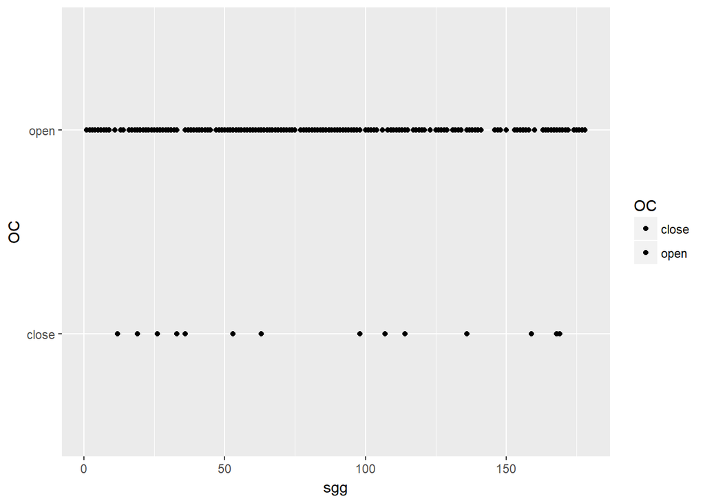

```r
train_dta %>%
  select(OC, sgg) %>%
  ggplot(aes(x = sgg, y = OC, fill = OC)) +
  geom_point()
```

On first glance, the `sgg` variable does not seem to be useful in our goal of trying to predict whether a hospital would close or not (well… not on its own, anyway).

Before we move on though, let’s check something first.

```r
length(unique(unlist(train_dta$sgg)))
```

```
## [1] 155
```

We are guessing that `sgg` is some kind of ID used to indicate the district where each hospital is located and this dataset consists of 155 distinct ones. Before we continue, let’s see if the test set contains any districts that do not exist in the training set.

```r
length(unique(union(unlist(train_dta$sgg),unlist(test_dta$sgg))))
```

```
## [1] 178
```

```r
length(unique(unlist(test_dta$sgg)))
```

```
## [1] 89
```

It seems that there are districts that exist in the test set and not in the training set. This may lead to the `sgg` variable being eliminated before training the prediction model later as it cannot be used to discriminate opening hospoital from closing ones (at least not in a straightforward manner).

```r
train_dta %>%
  group_by(sido,sgg) %>%
  summarise(count = n()) %>%
  arrange(sgg)
```

```
## # A tibble: 155 x 3
## # Groups: sido [16]
##    sido        sgg count
##    <chr>     <int> <int>
##  1 seoul         1     1
##  2 gangwon       2     2
##  3 seoul         3     1
##  4 seoul         4     3
##  5 gyeongnam     5     2
##  6 gyeongnam     6     1
##  7 gyeongbuk     7     4
##  8 gyeongbuk     8     6
##  9 choongnam     9     1
## 10 gyeongnam    11     1
## # ... with 145 more rows
```

The above command was to make sure that each `sgg` belongs to only one `sido` (i.e. that no `sgg` appears with more than one `sido` in the data). This makes sense as each district should only belong to one provinc/city (a district belonging to two provinces would not make sense).

```r
test_dta %>%
  group_by(sido,sgg) %>%
  summarise(count = n()) %>%
  arrange(sgg)
```

```
## # A tibble: 89 x 3
## # Groups: sido [15]
##    sido        sgg count
##    <chr>     <int> <int>
##  1 gyeongnam     6     1
##  2 gyeongbuk     8     3
##  3 gyeongbuk    10     1
##  4 gyeonggi     12     1
##  5 jeonnam      15     1
##  6 seoul        23     2
##  7 gyeonggi     24     1
##  8 gyeongbuk    25     1
##  9 jeonbuk      26     4
## 10 choongnam    28     1
## # ... with 79 more rows
```

The above command was to make sure that, for each `sgg` that existed in both the training and test data, it co-occured with the same `sido` in the training and test sets.

### openDate: Hospital establishment date

```r
# view some values of the 'openDate' variable
train_dta %>%
  select(openDate) %>%
  head()
```

```
## # A tibble: 6 x 1
##   openDate
##      <int>
## 1 20071228
## 2 19970401
## 3 20161228
## 4 20000814
## 5 20050901
## 6 20020501
```

Some parsing is in order. We shall separate it into three variables: year, month and day.

```r
# create new variables to hold the year/month/day values of 'openDate'
train_dta %>%
  mutate(openDateYYYY = substr(openDate,1,4),
         openDateMM = substr(openDate,5,6),
         openDateDD = substr(openDate,7,8)) %>%
  select(OC, openDateYYYY, openDateMM, openDateDD) %>%
  head()
```

```
## # A tibble: 6 x 4
##   OC    openDateYYYY openDateMM openDateDD
##   <chr> <chr>        <chr>      <chr>
## 1 open  2007         12         28
## 2 open  1997         04         01
## 3 open  2016         12         28
## 4 open  2000         08         14
## 5 open  2005         09         01
## 6 open  2002         05         01
```

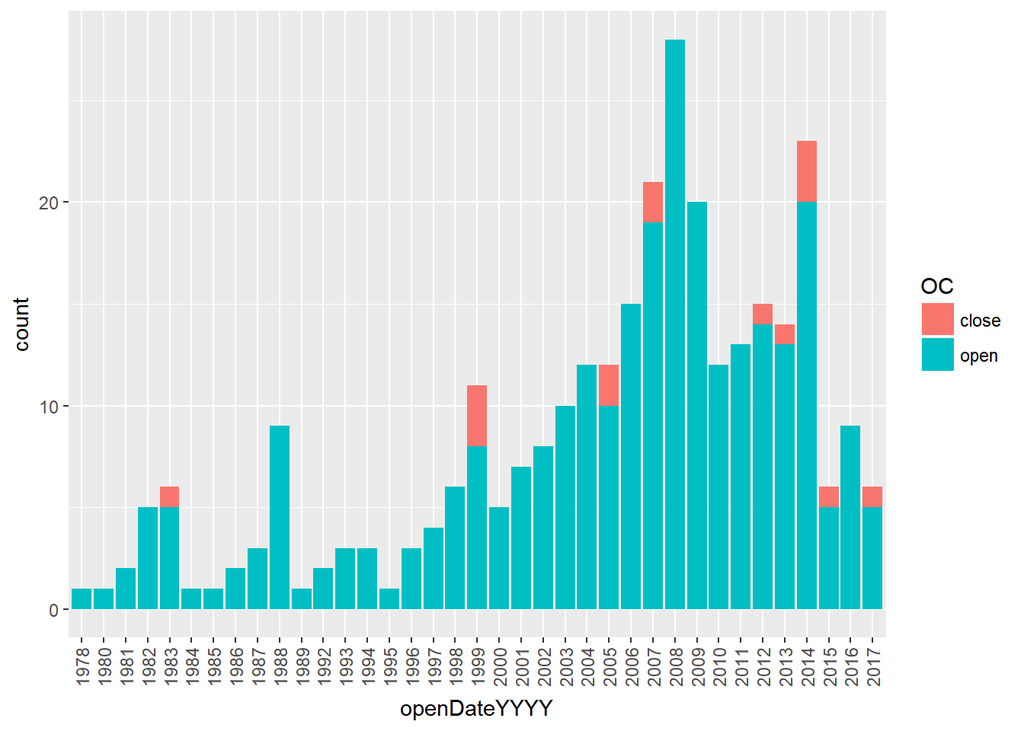

```r
# create new variables to hold the year/month/day values of 'openDate'
train_dta %>%
  mutate(openDateYYYY = substr(openDate,1,4),
         openDateMM = substr(openDate,5,6),
         openDateDD = substr(openDate,7,8)) %>%
  select(OC, openDateYYYY, openDateMM, openDateDD) %>%
  ggplot(aes(x = openDateYYYY, fill = OC)) +
  geom_bar() +
  theme(axis.text.x = element_text(angle=90, vjust=0.5))
```

It seems that older hospitals are less likely to close than newer ones.

For fun, let’s just see what the above plot looks like for `openDateMM`.

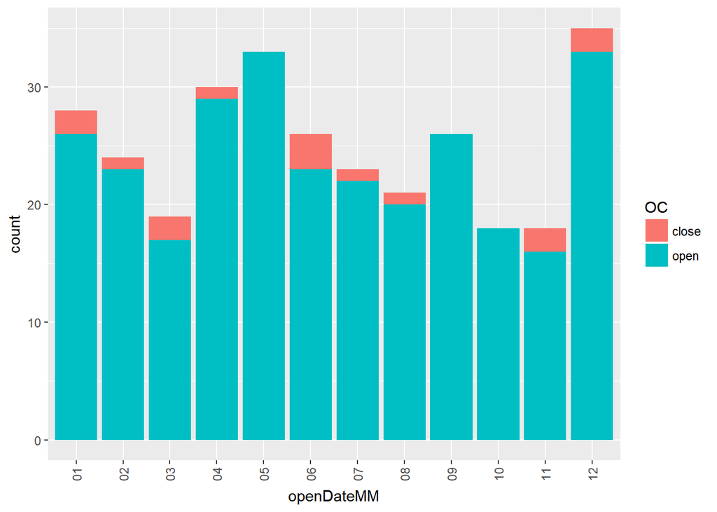

```r
# create new variables to hold the year/month/day values of 'openDate'
train_dta %>%
  mutate(openDateYYYY = substr(openDate,1,4),
         openDateMM = substr(openDate,5,6),
         openDateDD = substr(openDate,7,8)) %>%
  select(OC, openDateYYYY, openDateMM, openDateDD) %>%
  ggplot(aes(x = openDateMM, fill = OC)) +
  geom_bar() +
  theme(axis.text.x = element_text(angle=90, vjust=0.5))
```

### bedCount: Number of sickbeds

```r
summary(train_dta$bedCount)
```

```
##    Min. 1st Qu.  Median    Mean 3rd Qu.    Max.    NA's
##    0.00   52.75  136.50  145.71  193.00  656.00       5
```

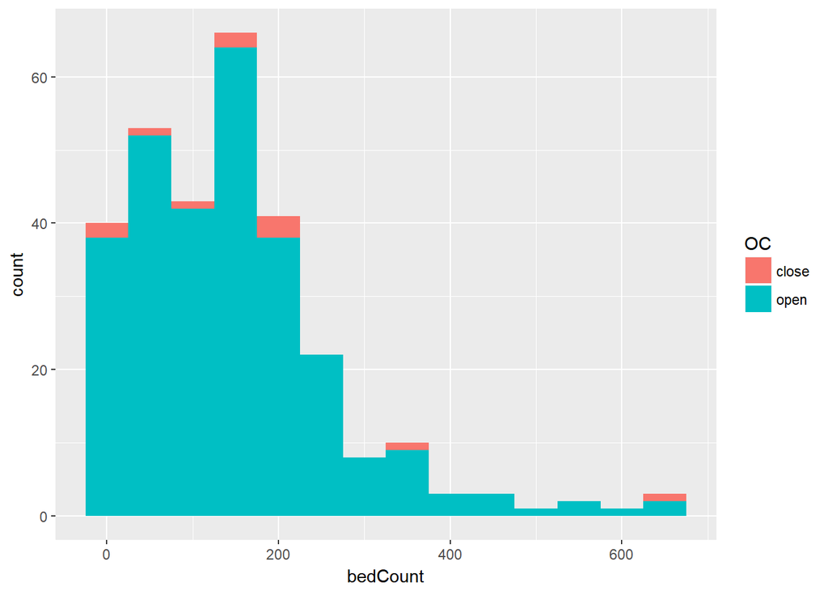

```r
train_dta %>%
  select(OC, bedCount) %>%
  filter(!is.na(bedCount)) %>%
  ggplot(aes(x = bedCount, fill = OC)) +
  geom_histogram(binwidth = 50)
```

Finally, something worth noting. It seems that hospitals that have a greater-than-average number of sickbeds tend to stay open (with a few rare exceptions). Let’s have a look at the hospitals that have `NA` values in the `bedCount` variable.

```r
train_dta %>%
  select(OC, bedCount) %>%
  filter(is.na(bedCount))
```

```
## # A tibble: 5 x 2
##   OC    bedCount
##   <chr>    <int>
## 1 close       NA
## 2 close       NA
## 3 close       NA
## 4 close       NA
## 5 open        NA
```

For whatever it is worth, the hospitals having `NA` values in the `bedCount` variable are usually ones that eventually `close`. This finding is to be taken with a grain of salt since it is based on only 5 records.

There are some records that a value of `0` in the `bedCount` variable. Let’s look at these too.

```r
train_dta %>%
  select(OC, bedCount) %>%
  filter(bedCount == 0) %>%
  group_by(OC) %>%
  summarise(count = n())
```

```
## # A tibble: 2 x 2
##   OC    count
##   <chr> <int>
## 1 close     2
## 2 open     20
```

Similar to the distribution observed from the entire training data, the majority of the hospitals having a value of `0` in the `bedCount` variable are `open`. Nothing interesting to report here.

### instkind: Sort of hospital

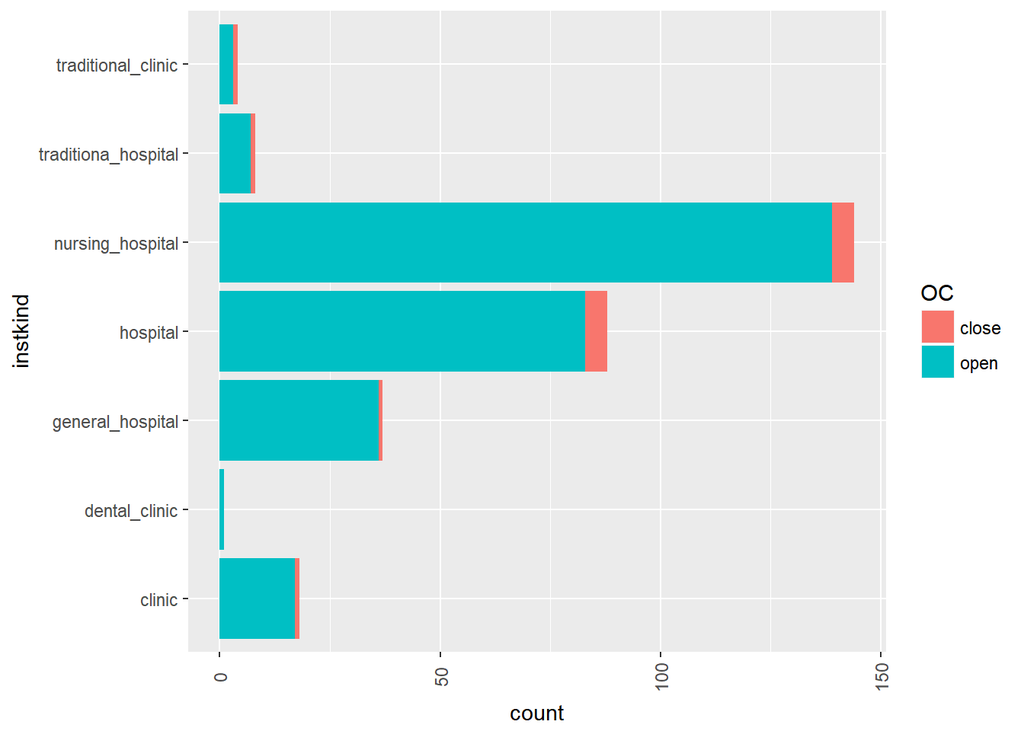

```r
train_dta %>%
  select(OC, instkind) %>%
  filter(!is.na(instkind)) %>%
  ggplot(aes(x = instkind, fill = OC)) +
  geom_bar() +
  theme(axis.text.x = element_text(angle=90, vjust=0.5)) +
  coord_flip()
```

Each of the seven types of hospitals had its failed ventures. No one type of hospitals was 100% successful (except for `dental_clinic`).

### employee1: Number of employees employed (fiscal year 2017)

```r
train_dta$employee1 <- as.numeric(train_dta$employee1)
summary(train_dta$employee1)
```

```
##    Min. 1st Qu.  Median    Mean 3rd Qu.    Max.    NA's
##     1.0    54.0    80.0   143.0   182.2  1200.0      11
```

```r
head(sort(train_dta$employee1), 20)
```

```
##  [1]  1  1  1  4  4  7  9  9 11 14 15 15 15 16 16 17 20 20 21 21
```

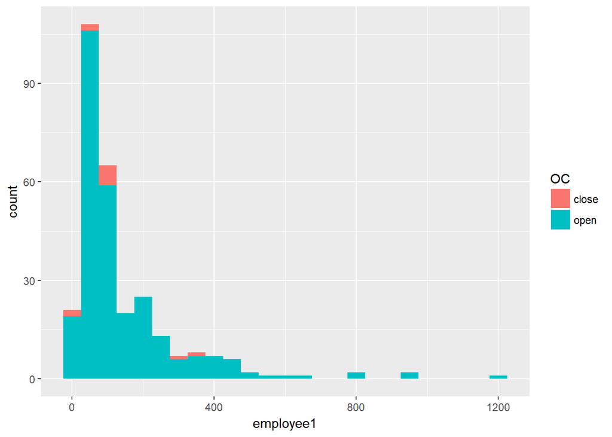

```r
train_dta %>%
  select(OC, employee1) %>%
  filter(!is.na(employee1)) %>%
  ggplot(aes(x = employee1, fill = OC)) +
  geom_histogram(binwidth = 50)
```

```r
train_dta %>%
  select(OC, employee1) %>%
  filter(is.na(employee1))
```

```
## # A tibble: 11 x 2
##    OC    employee1
##    <chr>     <dbl>
##  1 open         NA
##  2 open         NA
##  3 close        NA
##  4 open         NA
##  5 open         NA
##  6 close        NA
##  7 open         NA
##  8 open         NA
##  9 open         NA
## 10 open         NA
## 11 close        NA
```

### employee2: Number of employees employed (fiscal year 2016)

```r
train_dta$employee2 <- as.numeric(train_dta$employee2)
summary(train_dta$employee2)
```

```
##    Min. 1st Qu.  Median    Mean 3rd Qu.    Max.    NA's
##    1.00   54.25   79.00  135.27  170.00 1200.00      15
```

```r
head(sort(train_dta$employee2), 20)
```

```
##  [1]  1  1  1  1  1  6  7  8  9 10 14 14 15 15 15 15 15 17 19 20
```

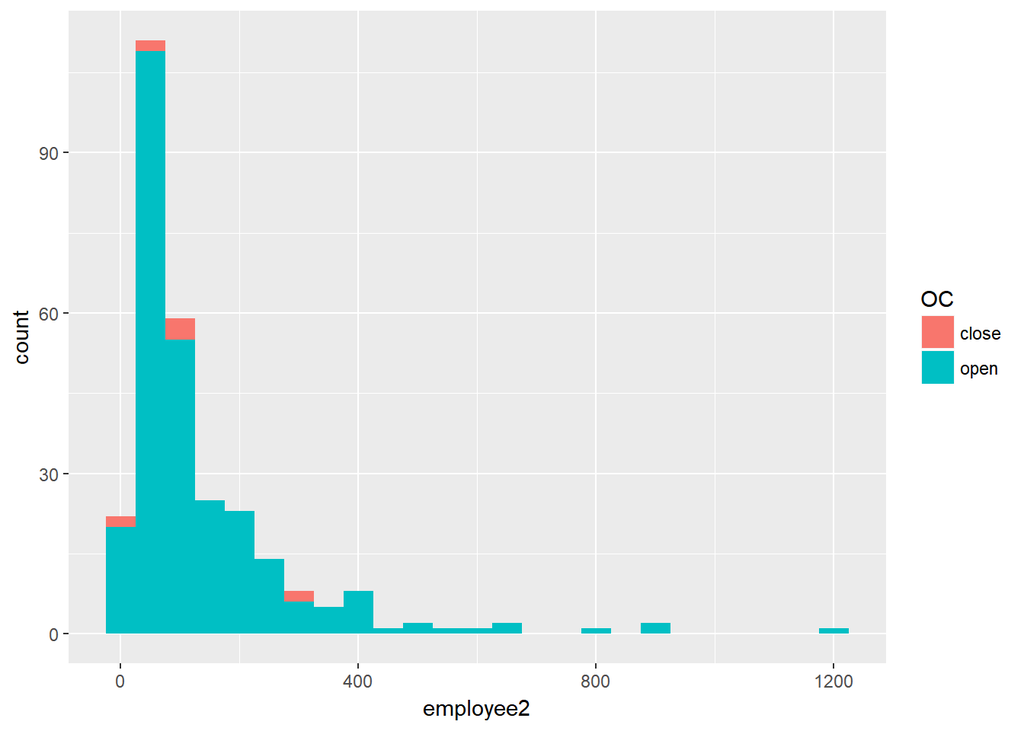

```r
train_dta %>%
  select(OC, employee2) %>%
  filter(!is.na(employee2)) %>%
  ggplot(aes(x = employee2, fill = OC)) +
  geom_histogram(binwidth = 50)
```

```r
train_dta %>%
  select(OC, employee2) %>%
  filter(is.na(employee2))
```

```
## # A tibble: 15 x 2
##    OC    employee2
##    <chr>     <dbl>
##  1 close        NA
##  2 open         NA
##  3 open         NA
##  4 open         NA
##  5 close        NA
##  6 open         NA
##  7 open         NA
##  8 close        NA
##  9 open         NA
## 10 open         NA
## 11 open         NA
## 12 open         NA
## 13 open         NA
## 14 close        NA
## 15 close        NA
```

```r
train_dta %>%
  select(employee1, employee2) %>%
  filter(!is.na(employee1) & !is.na(employee2)) %>%
  as.matrix() %>%
  cor()
```

```
##           employee1 employee2
## employee1 1.0000000 0.9744522
## employee2 0.9744522 1.0000000
```

### ownerChange: change of company representative

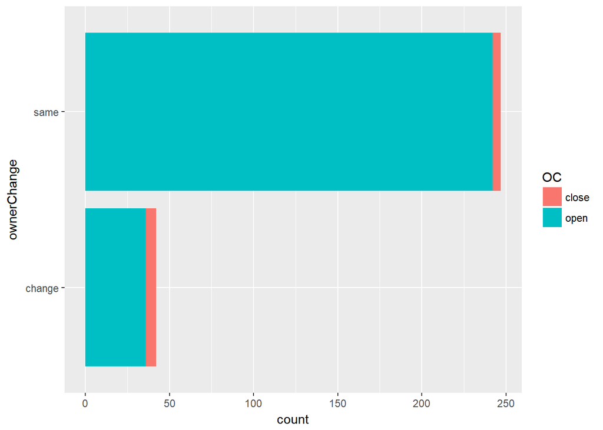

```r
train_dta %>%
  select(OC, ownerChange) %>%
  filter(!is.na(ownerChange)) %>%
  ggplot(aes(x = ownerChange, fill = OC)) +
  geom_bar() +
  coord_flip()
```

It does not seem that value of `ownerChange` matters much, although proportions-wise, it seems that the hospitals that had an owner change had a bigger portion of failed hospitals than those that did not have an owner change. That is to say, when a hospital gets an owner change, the hospital becomes more likely to close. For example, the hospital may have been sold to another owner due to financial difficulties that the hospital was facing.

```r
train_dta %>%
  select(OC, ownerChange) %>%
  group_by(ownerChange) %>%
  summarise(open = sum(OC == "open"), close = sum(OC == "close")) %>%
  mutate(close_to_open_ratio = close/open)
```

```
## # A tibble: 3 x 4
##   ownerChange  open close close_to_open_ratio
##   <chr>       <int> <int>               <dbl>
## 1 change         36     6              0.167
## 2 same          242     5              0.0207
## 3 <NA>            8     4              0.5
```

### Variables of Fiscal Years, 2016 & 2017

Before moving on with the rest of the variables let’s view the variables having the suffix `1` in a correlogram to sniff out any relations between them.

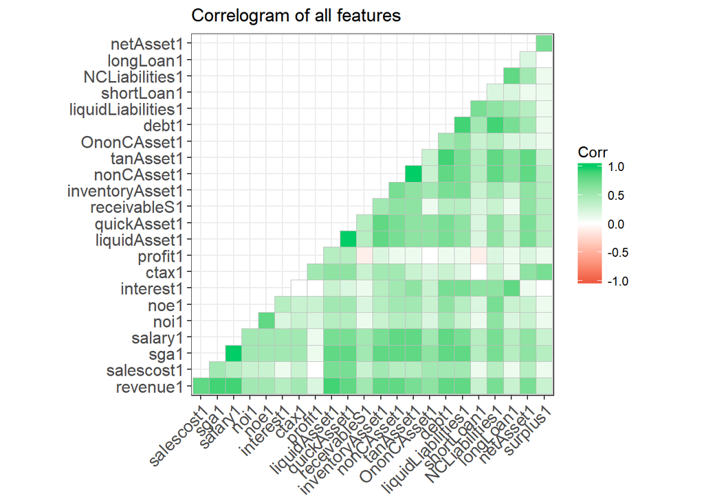

```r
# indices of rows (instances) containing NA values in them
row_indices <-
  train_dta %>%
  map_df(is.na) %>%                              # turn into an is.na() matrix
  transmute(rowHasNAvalue = rowSums(.) > 0) %>%  # create variable indicating whether the row has an NA value
  as.matrix() %>%                                # convert into matrix (for the following 'which' function)
  which()                                        # return indices of rows having NA values

# display a correlogram of all the variables together
train_dta[-row_indices,8:31] %>%
  cor() %>%                        # compute pairwise correlations
  round(1) %>%                     # round to one decimal point
  ggcorrplot(hc.order = FALSE,
             type = "lower",
             #lab = TRUE,
             #lab_size = 3,
             method="square",
             colors = c("tomato2", "white", "springgreen3"),
             title="Correlogram of all features",
             ggtheme=theme_bw)
```

The above figure shows an important observation. That is, most variables highly with each other. Some exceptions include `profit1`, `interest1`, `shortLoan1`, `longLoan1`, `OnonCAsset1` and `surplus1`. Based on the high correlations observed in the figure above, the plots that will be generated for the variables in the figure should look similar to one another.

### revenue1: revenue (fiscal year 2017)

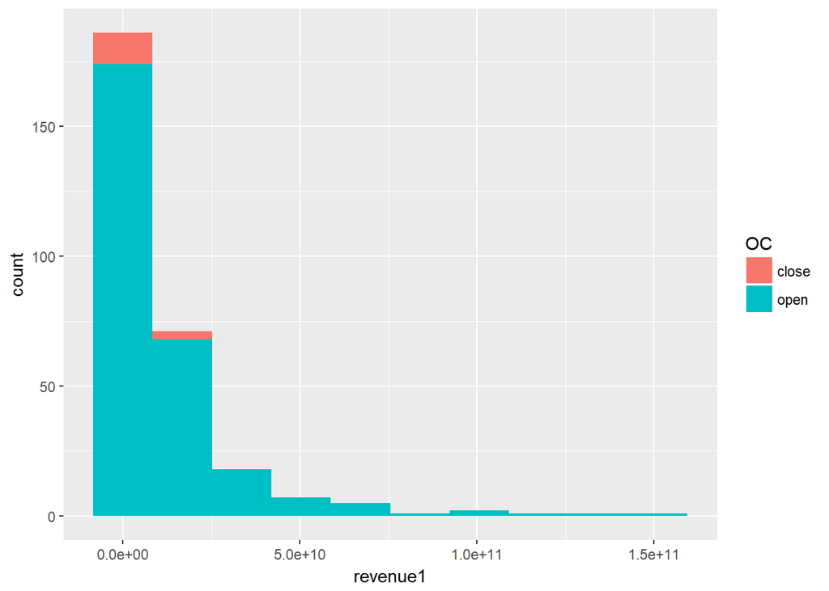

```r
train_dta %>%
  select(OC, revenue1) %>%
  filter(!is.na(revenue1)) %>%
  ggplot(aes(x = revenue1, fill = OC)) +
  geom_histogram(bins = 10)
```

Another finding worth mentioning; hospitals that `close` all seem to be at the lower end of the revenu scale. It may be useful to separate the data into two box plots (one for `open` hospitals and one for hospitals that `close`).

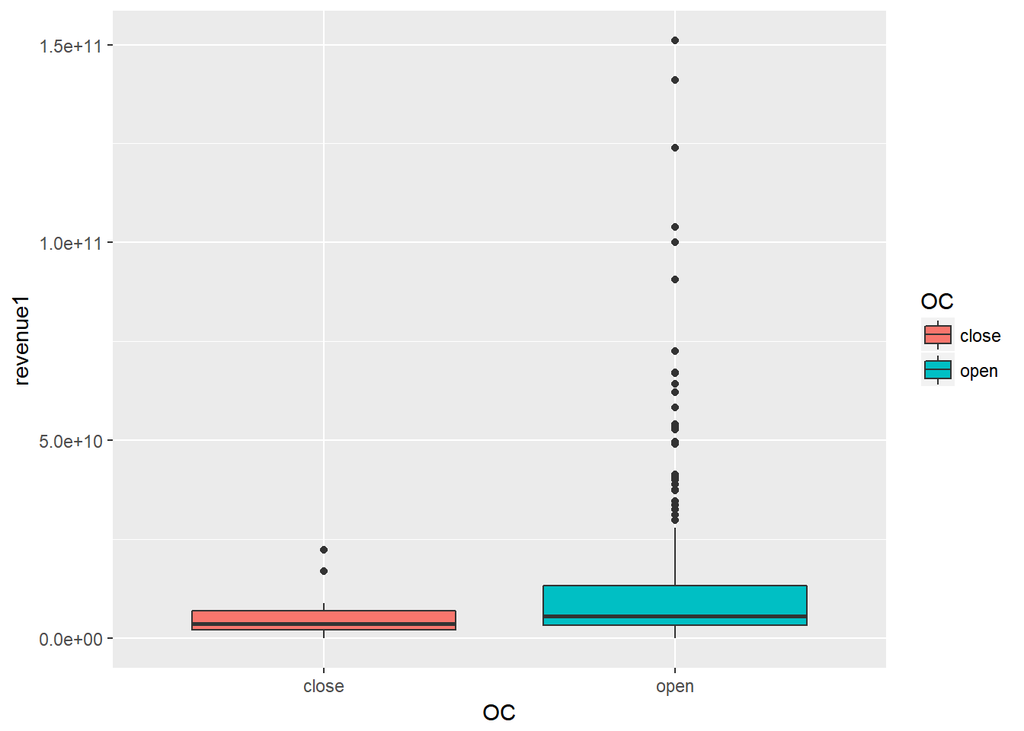

```r
train_dta %>%
  select(OC, revenue1) %>%
  filter(!is.na(revenue1)) %>%
  ggplot(aes(x = OC, y = revenue1, fill = OC)) +
  geom_boxplot()
```

Some of the hopsitals have the value `0` in the `revenue1` variable. Let’s check those out.

```r
train_dta %>%
  select(OC, revenue1) %>%
  filter(revenue1 == 0) %>%
  group_by(OC) %>%
  summarise(count = n())
```

```
## # A tibble: 2 x 2
##   OC    count
##   <chr> <int>
## 1 close     1
## 2 open      3
```

```r
train_dta %>%
  select(OC, revenue1) %>%
  filter(revenue1 > 0) %>%
  group_by(OC) %>%
  summarise(count = n())
```

```
## # A tibble: 2 x 2
##   OC    count
##   <chr> <int>
## 1 close    14
## 2 open    275
```

### salescost1: sales cost (fiscal year 2017)

```r
summary(train_dta$salescost1)
```

```
##      Min.   1st Qu.    Median      Mean   3rd Qu.      Max.      NA's
## 0.000e+00 0.000e+00 2.104e+08 2.015e+09 9.105e+08 9.850e+10         8
```

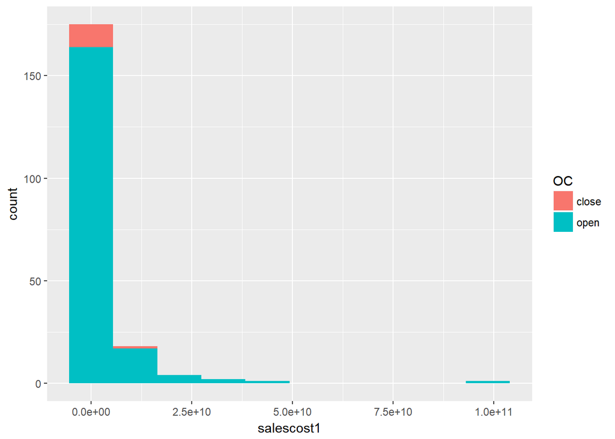

```r
train_dta %>%
  select(OC, salescost1) %>%
  filter(!is.na(salescost1)) %>%
  filter(salescost1 > 0) %>%
  ggplot(aes(x = salescost1, fill = OC)) +
  geom_histogram(bins = 10)
```

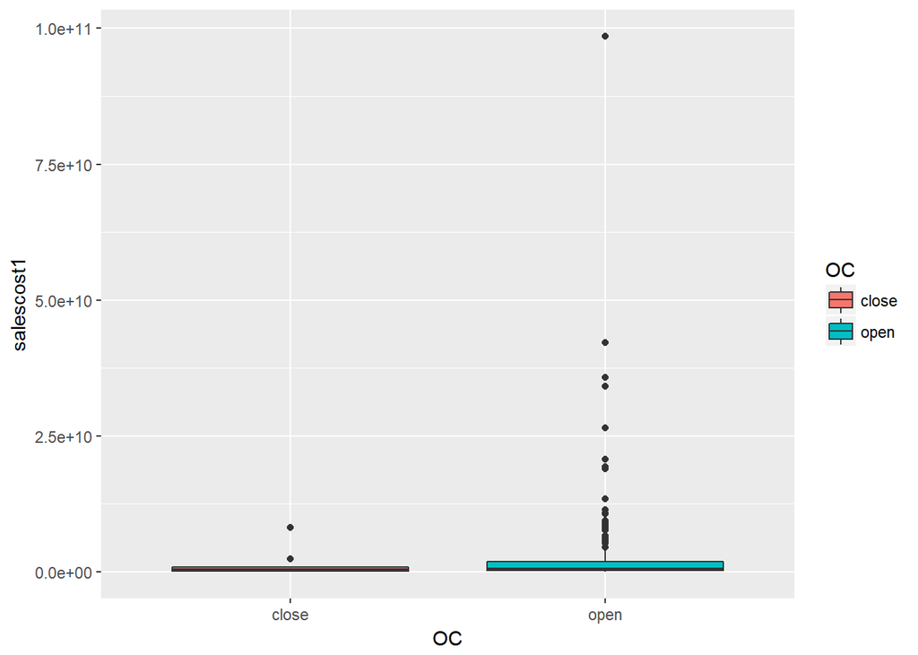

```r
train_dta %>%
  select(OC, salescost1) %>%
  filter(!is.na(salescost1)) %>%
  filter(salescost1 != 0) %>%
  #ggplot(aes(x = OC, y = log(salescost1), fill = OC)) +
  ggplot(aes(x = OC, y = salescost1, fill = OC)) +
  geom_boxplot()
```

### sga1: selling and general administrative expense (fiscal year 2017)

```r
train_dta %>%
  select(OC, sga1) %>%
  summary()
```

```
##       OC                 sga1
##  Length:301         Min.   :0.000e+00
##  Class :character   1st Qu.:2.758e+09
##  Mode  :character   Median :4.684e+09
##                     Mean   :1.033e+10
##                     3rd Qu.:1.078e+10
##                     Max.   :1.030e+11
##                     NA's   :8
```

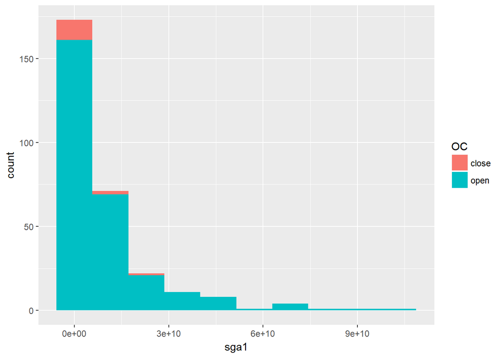

```r
train_dta %>%
  select(OC, sga1) %>%
  filter(!is.na(sga1)) %>%
  ggplot(aes(x = sga1, fill = OC)) +
  geom_histogram(bins = 10)
```

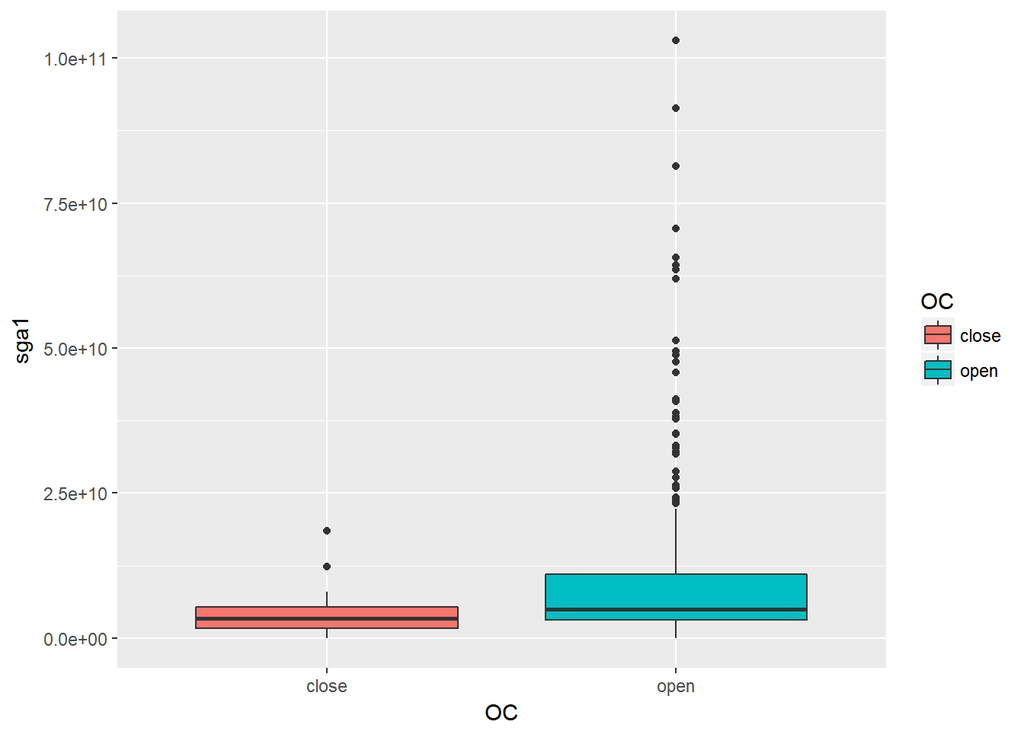

```r
train_dta %>%
  select(OC, sga1) %>%
  filter(!is.na(sga1)) %>%
  filter(sga1 != 0) %>%
  ggplot(aes(x = OC, y = sga1, fill = OC)) +
  geom_boxplot()
```

```r
train_dta %>%
  select(OC, sga1) %>%
  filter(sga1 == 0) %>%
  group_by(OC) %>%
  summarise(count = n())
```

```
## # A tibble: 2 x 2
##   OC    count
##   <chr> <int>
## 1 close     1
## 2 open      4
```

### salary1: salary account (fiscal year 2017)

```r
train_dta %>%
  select(OC, salary1) %>%
  summary()
```

```
##       OC               salary1
##  Length:301         Min.   :0.000e+00
##  Class :character   1st Qu.:1.626e+09
##  Mode  :character   Median :2.660e+09
##                     Mean   :5.654e+09
##                     3rd Qu.:6.363e+09
##                     Max.   :6.404e+10
##                     NA's   :8
```

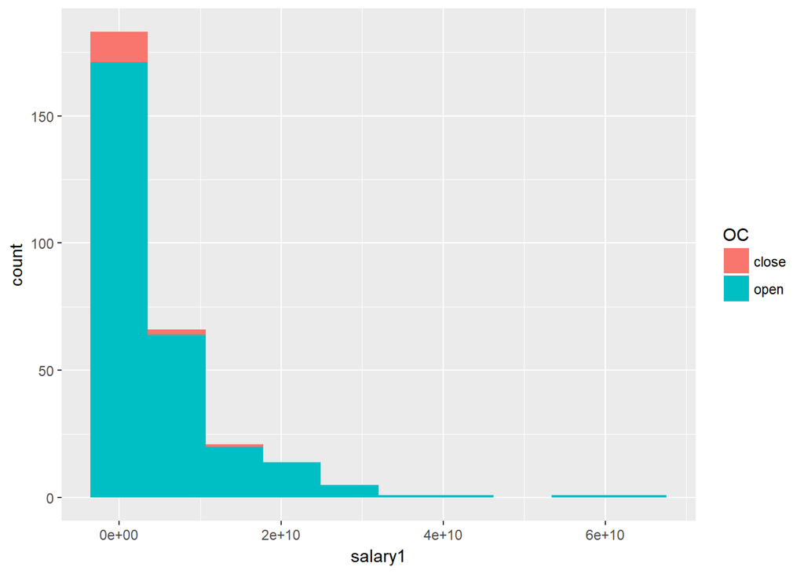

```r
train_dta %>%
  select(OC, salary1) %>%
  filter(!is.na(salary1)) %>%
  ggplot(aes(x = salary1, fill = OC)) +
  geom_histogram(bins = 10)
```

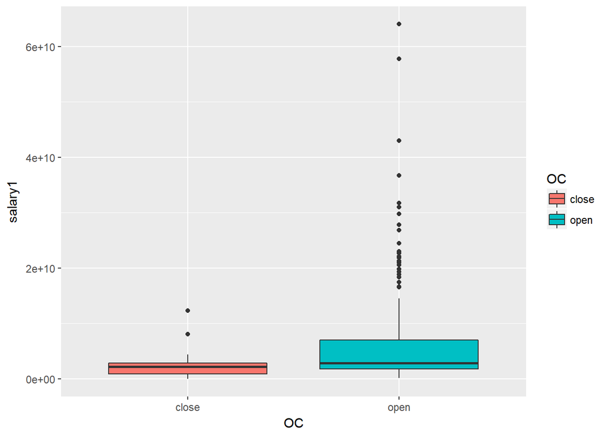

```r
train_dta %>%
  select(OC, salary1) %>%
  filter(!is.na(salary1)) %>%
  filter(salary1 != 0) %>%
  ggplot(aes(x = OC, y = salary1, fill = OC)) +
  geom_boxplot()
```

```r
train_dta %>%
  select(OC, salary1) %>%
  filter(salary1 == 0) %>%
  group_by(OC) %>%
  summarise(count = n())
```

```
## # A tibble: 2 x 2
##   OC    count
##   <chr> <int>
## 1 close     1
## 2 open     10
```

### noi1: non-operating income (fiscal year 2017)

```r
train_dta %>%
  select(OC, noi1) %>%
  summary()
```

```
##       OC                 noi1
##  Length:301         Min.   :0.000e+00
##  Class :character   1st Qu.:8.217e+06
##  Mode  :character   Median :4.364e+07
##                     Mean   :2.696e+08
##                     3rd Qu.:2.050e+08
##                     Max.   :9.144e+09
##                     NA's   :8
```

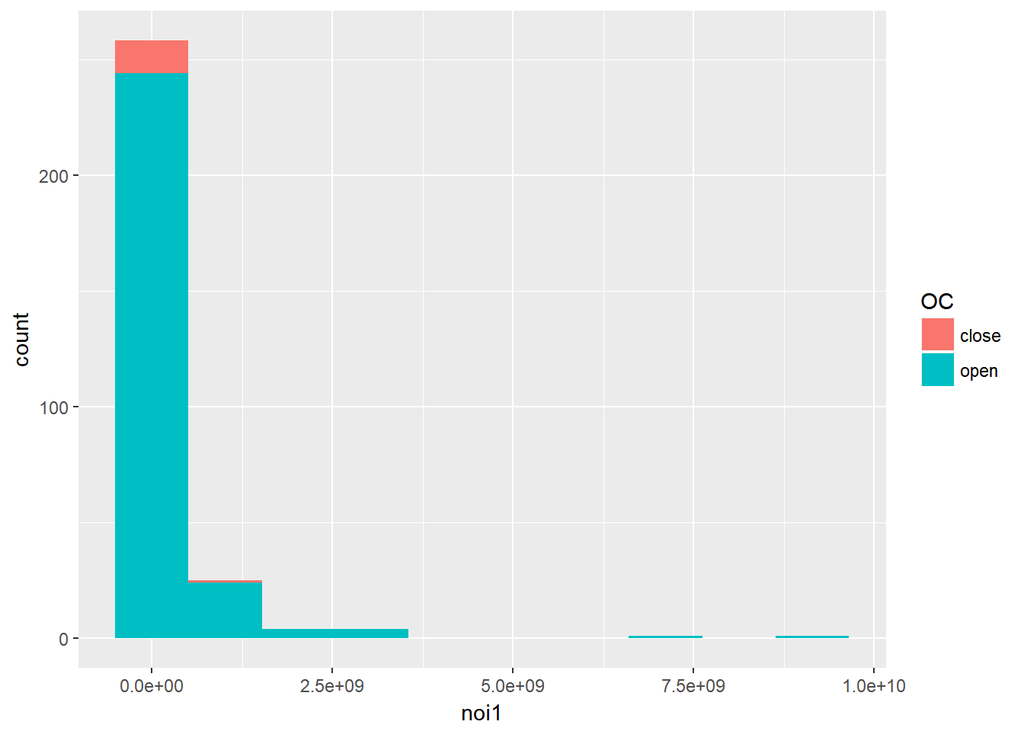

```r
train_dta %>%
  select(OC, noi1) %>%
  filter(!is.na(noi1)) %>%
  ggplot(aes(x = noi1, fill = OC)) +
  geom_histogram(bins = 10)
```

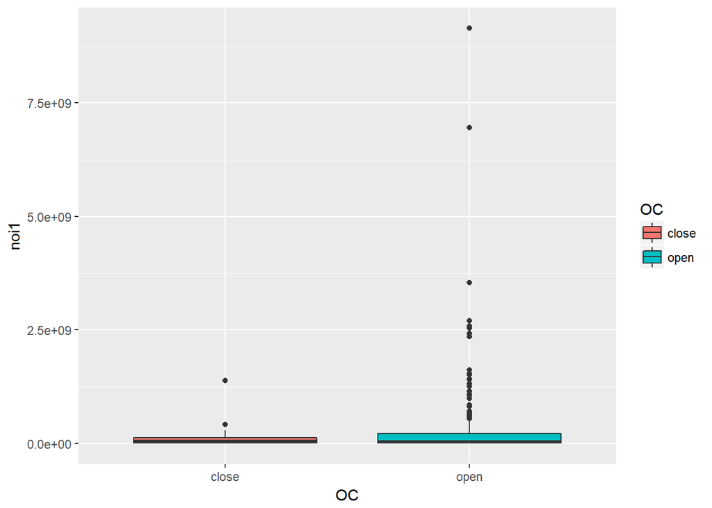

```r
train_dta %>%
  select(OC, noi1) %>%
  filter(!is.na(noi1)) %>%
  filter(noi1 != 0) %>%
  ggplot(aes(x = OC, y = noi1, fill = OC)) +
  geom_boxplot()
```

```r
train_dta %>%
  select(OC, noi1) %>%
  filter(noi1 == 0) %>%
  group_by(OC) %>%
  summarise(count = n())
```

```
## # A tibble: 1 x 2
##   OC    count
##   <chr> <int>
## 1 open      8
```

### noe1: non-operating expenses (fiscal year 2017)

```r
train_dta %>%
  select(OC, noe1) %>%
  summary()
```

```
##       OC                 noe1
##  Length:301         Min.   :0.000e+00
##  Class :character   1st Qu.:8.013e+07
##  Mode  :character   Median :1.832e+08
##                     Mean   :5.116e+08
##                     3rd Qu.:4.203e+08
##                     Max.   :8.686e+09
##                     NA's   :8
```

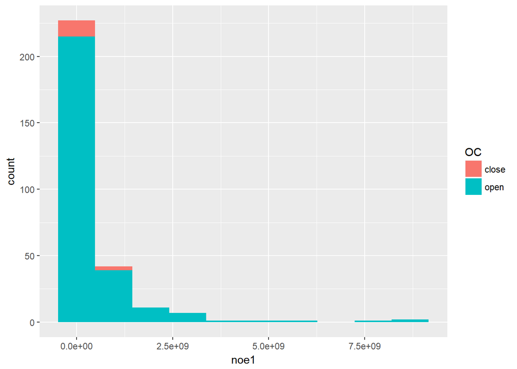

```r
train_dta %>%
  select(OC, noe1) %>%
  filter(!is.na(noe1)) %>%
  ggplot(aes(x = noe1, fill = OC)) +
  geom_histogram(bins = 10)
```

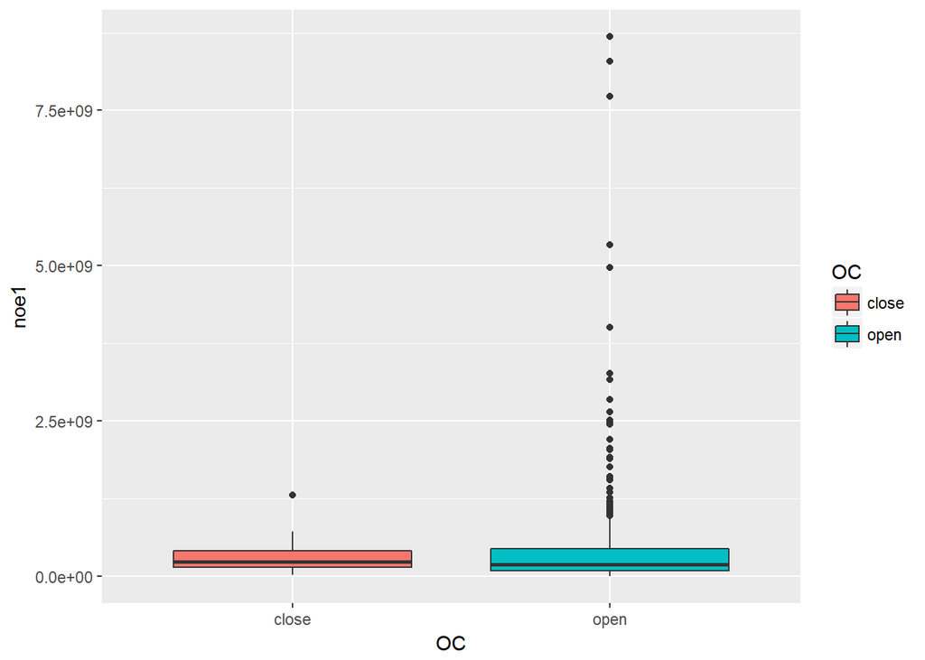

```r
train_dta %>%
  select(OC, noe1) %>%
  filter(!is.na(noe1)) %>%
  filter(noe1 != 0) %>%
  ggplot(aes(x = OC, y = noe1, fill = OC)) +
  geom_boxplot()
```

```r
train_dta %>%
  select(OC, noe1) %>%
  filter(noe1 == 0) %>%
  group_by(OC) %>%
  summarise(count = n())
```

```
## # A tibble: 1 x 2
##   OC    count
##   <chr> <int>
## 1 open     12
```

### interest1: interest cost (fiscal year 2017)

```r
train_dta %>%
  select(OC, interest1) %>%
  summary()
```

```
##       OC              interest1
##  Length:301         Min.   :0.000e+00
##  Class :character   1st Qu.:5.066e+07
##  Mode  :character   Median :1.097e+08
##                     Mean   :1.869e+08
##                     3rd Qu.:2.242e+08
##                     Max.   :2.841e+09
##                     NA's   :8
```

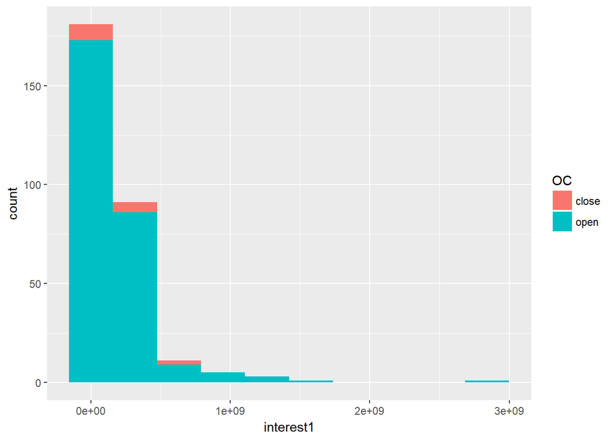

```r
train_dta %>%
  select(OC, interest1) %>%
  filter(!is.na(interest1)) %>%
  ggplot(aes(x = interest1, fill = OC)) +
  geom_histogram(bins = 10)
```

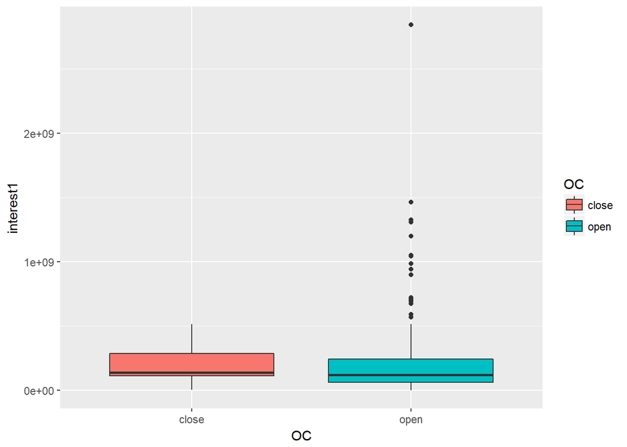

```r
train_dta %>%
  select(OC, interest1) %>%
  filter(!is.na(interest1)) %>%
  filter(interest1 != 0) %>%
  ggplot(aes(x = OC, y = interest1, fill = OC)) +
  geom_boxplot()
```

```r
train_dta %>%
  select(OC, interest1) %>%
  filter(interest1 == 0) %>%
  group_by(OC) %>%
  summarise(count = n())
```

```
## # A tibble: 1 x 2
##   OC    count
##   <chr> <int>
## 1 open     26
```

```r
train_dta %>%
  select(OC, interest1) %>%
  filter(interest1 != 0) %>%
  group_by(OC) %>%
  summarise(count = n())
```

```
## # A tibble: 2 x 2
##   OC    count
##   <chr> <int>
## 1 close    15
## 2 open    252
```

### ctax1: corporate tax (fiscal year 2017)

```r
train_dta %>%
  select(OC, ctax1) %>%
  summary()
```

```
##       OC                ctax1
##  Length:301         Min.   :0.000e+00
##  Class :character   1st Qu.:0.000e+00
##  Mode  :character   Median :1.025e+06
##                     Mean   :7.847e+07
##                     3rd Qu.:4.435e+07
##                     Max.   :2.809e+09
##                     NA's   :8
```

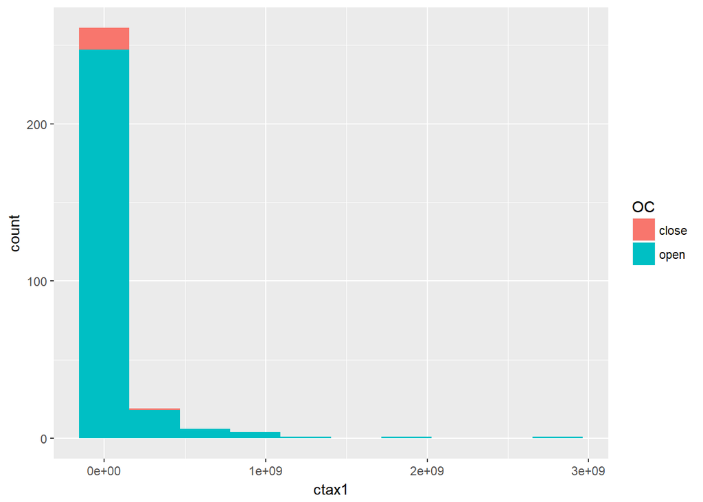

```r
train_dta %>%
  select(OC, ctax1) %>%
  filter(!is.na(ctax1)) %>%
  ggplot(aes(x = ctax1, fill = OC)) +
  geom_histogram(bins = 10)
```

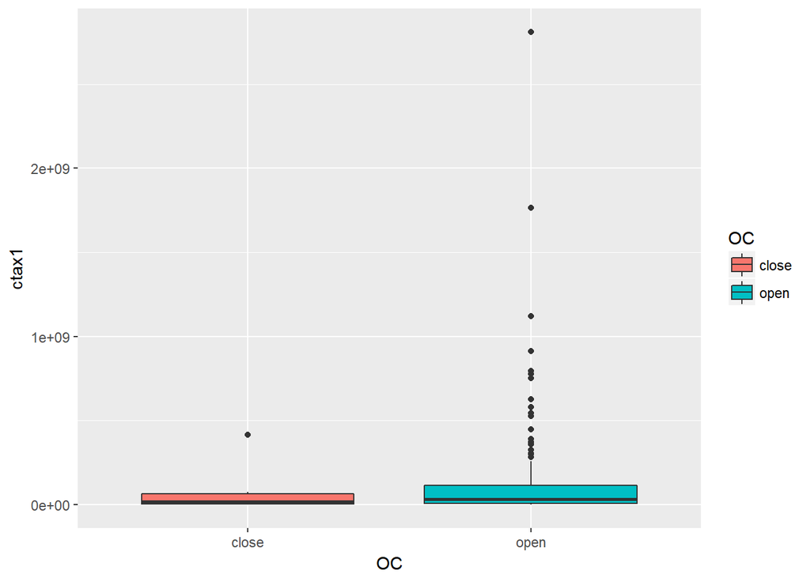

```r
train_dta %>%
  select(OC, ctax1) %>%
  filter(!is.na(ctax1)) %>%
  filter(ctax1 != 0) %>%
  ggplot(aes(x = OC, y = ctax1, fill = OC)) +
  geom_boxplot()
```

```r
train_dta %>%
  select(OC, ctax1) %>%
  filter(ctax1 == 0) %>%
  group_by(OC) %>%
  summarise(count = n())
```

```
## # A tibble: 2 x 2
##   OC    count
##   <chr> <int>
## 1 close     9
## 2 open    120
```

### profit1: net profit during the term (fiscal year 2017)

```r
train_dta %>%
  select(OC, profit1) %>%
  summary()
```

```
##       OC               profit1
##  Length:301         Min.   :-4.697e+09
##  Class :character   1st Qu.:-2.168e+06
##  Mode  :character   Median : 8.131e+07
##                     Mean   : 2.102e+08
##                     3rd Qu.: 2.930e+08
##                     Max.   : 7.475e+09
##                     NA's   :8
```

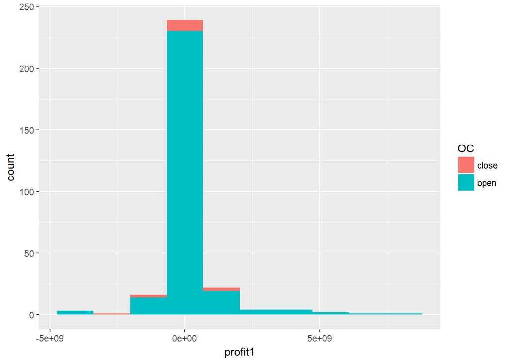

```r
train_dta %>%
  select(OC, profit1) %>%
  filter(!is.na(profit1)) %>%
  ggplot(aes(x = profit1, fill = OC)) +
  geom_histogram(bins = 10)
```

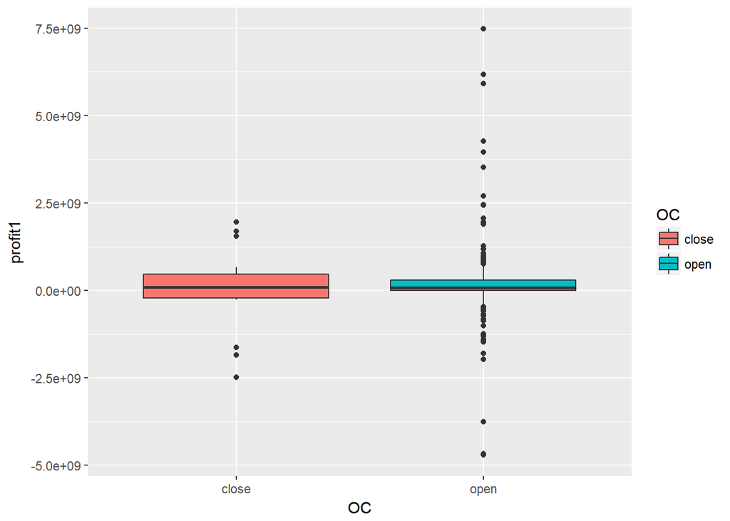

```r
train_dta %>%
  select(OC, profit1) %>%
  filter(!is.na(profit1)) %>%
  filter(profit1 != 0) %>%
  ggplot(aes(x = OC, y = profit1, fill = OC)) +
  geom_boxplot()
```

```r
train_dta %>%
  select(OC, profit1) %>%
  filter(profit1 > 0) %>%
  group_by(OC) %>%
  summarise(count = n())
```

```
## # A tibble: 2 x 2
##   OC    count
##   <chr> <int>
## 1 close     9
## 2 open    207
```

```r
train_dta %>%
  select(OC, profit1) %>%
  filter(profit1 == 0) %>%
  group_by(OC) %>%
  summarise(count = n())
```

```
## # A tibble: 1 x 2
##   OC    count
##   <chr> <int>
## 1 open      3
```

```r
train_dta %>%
  select(OC, profit1) %>%
  filter(profit1 < 0) %>%
  group_by(OC) %>%
  summarise(count = n())
```

```
## # A tibble: 2 x 2
##   OC    count
##   <chr> <int>
## 1 close     6
## 2 open     68
```

### liquidAsset1: liquid asset (fiscal year 2017)

```r
train_dta %>%
  select(OC, liquidAsset1) %>%
  summary()
```

```
##       OC             liquidAsset1
##  Length:301         Min.   :0.000e+00
##  Class :character   1st Qu.:7.199e+08
##  Mode  :character   Median :1.517e+09
##                     Mean   :3.537e+09
##                     3rd Qu.:3.379e+09
##                     Max.   :4.281e+10
##                     NA's   :8
```

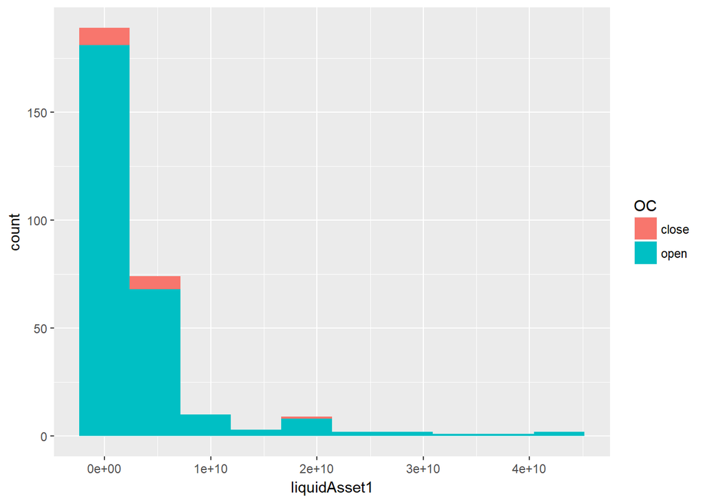

```r
train_dta %>%
  select(OC, liquidAsset1) %>%
  filter(!is.na(liquidAsset1)) %>%
  ggplot(aes(x = liquidAsset1, fill = OC)) +
  geom_histogram(bins = 10)
```

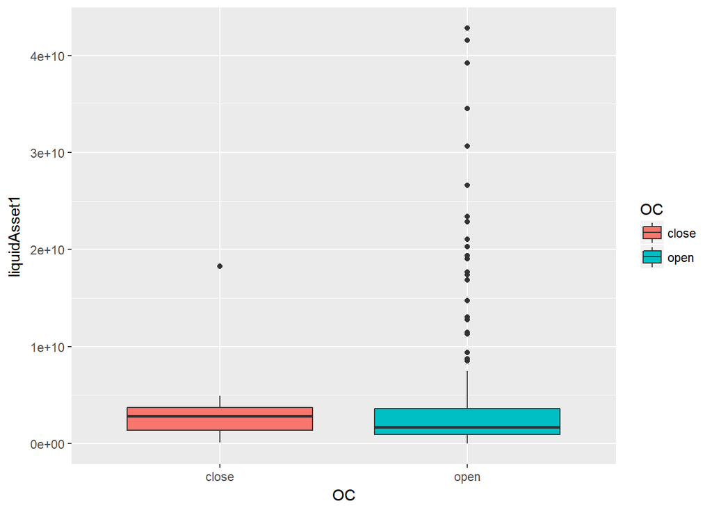

```r
train_dta %>%
  select(OC, liquidAsset1) %>%
  filter(!is.na(liquidAsset1)) %>%
  filter(liquidAsset1 != 0) %>%
  ggplot(aes(x = OC, y = liquidAsset1, fill = OC)) +
  geom_boxplot()
```

```r
train_dta %>%
  select(OC, liquidAsset1) %>%
  filter(liquidAsset1 == 0) %>%
  group_by(OC) %>%
  summarise(count = n())
```

```
## # A tibble: 2 x 2
##   OC    count
##   <chr> <int>
## 1 close     4
## 2 open     22
```